# MA710 Assignment4 - Decision Tree Classification and K-nearest Neighbors Classification

Xiang Li, Xue Zhou

4/24/2017

# Table of Contents

- 1 Introduction
- 2 Data Preparation
  - 2.1 Load the Data
  - 2.2 Testing and Training Data Set
- 3 Decision Tree Classification
- 4 k-Nearest Neighbour Classification
- 5 Conclusion
- 6 Future Studies

# 1 Introduction

In this analysis, we are going to use **Decision Tree** model and **K-nearest Neighbours** model to classify the `Control_factor` variable (which has three levels: private for-profit, private non-profit and public ) in the College Scorecard Data Set. Since we can get the control type information of a school by simply goggling, the goal of the analysis is to profile the institutions of each control type rather than to predict which control type a school belongs to.

# 2 Data Preparation

Prior to the analysis, we need to prepare the data. Getting a clean data set ready for Decision Tree Modeling and KNN Analysis requires us to remove unnecessary columns, deal with missing values, and split data into training and testing sets.

## 2.1 Load the dataset

We load the data set and take a look at the structure of data.

```r
data_import = read.csv("data_clean.csv",
                   header = TRUE, na.strings = 'NA')
str(data_import)
```

```
## 'data.frame':    7793 obs. of  19 variables:
##  $ X                : int  1 2 3 4 5 6 7 8 9 10 ...
##  $ UNITID           : int  100654 100663 100690 100706 100724 100751 100760 100812 100830 100858 ...
##  $ INSTNM_factor    : Factor w/ 7630 levels "A & W Healthcare Educators",..: 107 6823 255 6824 110 6557 1185 407 422 421 ...
##  $ STABBR_factor    : Factor w/ 59 levels "AK","AL","AR",..: 2 2 2 2 2 2 2 2 2 2 ...
##  $ PREDDEG_factor   : Factor w/ 5 levels "Associate's-degree",..: 2 2 2 2 2 2 1 2 2 2 ...
##  $ Control_factor   : Factor w/ 3 levels "Private For-profit",..: 3 3 2 3 3 3 3 3 3 3 ...
##  $ NPT4_COMBINE     : int  11726 15123 6927 11160 11029 18526 731 NA 11419 16284 ...
##  $ DEP_STAT_PCT_IND : num  0.158 0.33 0.907 0.378 0.181 ...
##  $ PAR_ED_PCT_1STGEN: num  0.37 0.346 0.496 0.325 0.404 ...
##  $ MD_FAMINC        : num  22681 35360 18410 33377 20445 ...
##  $ PCTPELL          : num  0.701 0.368 0.869 0.335 0.775 ...
##  $ PCTFLOAN         : num  0.793 0.553 0.968 0.479 0.816 ...
##  $ GRAD_DEBT_MDN    : num  30000 20500 20168 21500 31000 ...
##  $ WDRAW_DEBT_MDN   : num  10064 8650 5644 8306 9500 ...
##  $ APPL_SCH_PCT_GE2 : num  0.735 0.499 0.638 0.519 0.68 ...
##  $ MD_EARN_WNE_P6   : int  22000 33300 35200 35900 20300 33200 23800 33600 28300 36400 ...
##  $ MD_EARN_WNE_P10  : int  30300 39700 40100 45500 26600 41900 27500 39000 35000 45700 ...
##  $ RPY_3YR_RT_SUPP  : num  0.243 0.548 0.32 0.573 0.169 ...
##  $ CDR3             : num  0.165 0.07 0.075 0.084 0.19 0.082 0.259 0.078 0.137 0.064 ...
```

The original data set has 7793 observations and 19 variables.

First of all, we removed useless columns and renamed the row names as University ID. Then we dropped all the instances with missing values.

```r
#get rid of ID, university name and state columns, rename the rownames as the university ID.
data.with.rownames <- data.frame(data_import[,-c(1:4)], row.names=data_import[,2])

data_nomissing <- na.omit(data.with.rownames)

str(data_nomissing)  #4528 * 15
```

```
## 'data.frame':    4528 obs. of  15 variables:
##  $ PREDDEG_factor   : Factor w/ 5 levels "Associate's-degree",..: 2 2 2 2 2 2 2 2 2 1 ...
##  $ Control_factor   : Factor w/ 3 levels "Private For-profit",..: 3 3 2 3 3 3 3 3 2 3 ...
##  $ NPT4_COMBINE     : int  11726 15123 6927 11160 11029 18526 11419 16284 22544 1190 ...
##  $ DEP_STAT_PCT_IND : num  0.158 0.33 0.907 0.378 0.181 ...
##  $ PAR_ED_PCT_1STGEN: num  0.37 0.346 0.496 0.325 0.404 ...
##  $ MD_FAMINC        : num  22681 35360 18410 33377 20445 ...
##  $ PCTPELL          : num  0.701 0.368 0.869 0.335 0.775 ...
##  $ PCTFLOAN         : num  0.793 0.553 0.968 0.479 0.816 ...
##  $ GRAD_DEBT_MDN    : num  30000 20500 20168 21500 31000 ...
##  $ WDRAW_DEBT_MDN   : num  10064 8650 5644 8306 9500 ...
##  $ APPL_SCH_PCT_GE2 : num  0.735 0.499 0.638 0.519 0.68 ...
##  $ MD_EARN_WNE_P6   : int  22000 33300 35200 35900 20300 33200 28300 36400 26600 21000 ...
##  $ MD_EARN_WNE_P10  : int  30300 39700 40100 45500 26600 41900 35000 45700 44200 26100 ...
##  $ RPY_3YR_RT_SUPP  : num  0.243 0.548 0.32 0.573 0.169 ...
##  $ CDR3             : num  0.165 0.07 0.075 0.084 0.19 0.082 0.137 0.064 0.091 0.254 ...
##  - attr(*, "na.action")=Class 'omit'  Named int [1:3265] 7 8 18 19 20 22 25 26 28 31 ...
##   .. ..- attr(*, "names")= chr [1:3265] "100760" "100812" "101240" "101277" ...
```

The new data set `data_nomissing` has 4528 rows and 15 variables.

## 2.2 Testing and Training

After obtaining a clean data set, let’s split the complete data into training and testing sets. The ratio of training sample size to testing sample size is **2:1**. Also, we exported the training and testing set to two separate csv files for easier access in the future.

```r
set.seed(2) #reproduce the results

# Store row numbers for training set: index_train
index_train <- sample(1:nrow(data_nomissing), 2 / 3 * nrow(data_nomissing))

# Create training set: data_training
data_training <- data_nomissing[index_train, ]

write.csv(data_training, file = "Data_training.csv")

# Create test set: data_testing
data_testing <- data_nomissing[-index_train, ]

write.csv(data_testing, file = "Data_testing.csv")
```

The file `Data_testing.csv` and `Data_training.csv` are ready for further references.

We imported the `Data_testing.csv` and `Data_training.csv`.

```r
data_d = read.csv("Data_training.csv",
                   header = TRUE, na.strings = 'NA')#includes the row.names, just for testing
data_d2 = read.csv("Data_testing.csv",
                   header = TRUE, na.strings = 'NA')


data_training <- data.frame(data_d[,-1], row.names=data_d[,1])
str(data_training)
```

```
## 'data.frame':    3018 obs. of  15 variables:
##  $ PREDDEG_factor   : Factor w/ 4 levels "Associate's-degree",..: 3 1 2 2 1 2 3 1 1 1 ...
##  $ Control_factor   : Factor w/ 3 levels "Private For-profit",..: 1 1 2 2 1 3 1 1 3 2 ...
##  $ NPT4_COMBINE     : int  12450 16419 11297 20518 17758 17991 16676 21221 20028 28494 ...
##  $ DEP_STAT_PCT_IND : num  0.6943 0.6673 0.4578 0.0271 0.7349 ...
##  $ PAR_ED_PCT_1STGEN: num  0.634 0.462 0.466 0.226 0.389 ...
##  $ MD_FAMINC        : num  15235 17901 31661 66943 22040 ...
##  $ PCTPELL          : num  0.44 0.49 0.516 0.275 0.734 ...
##  $ PCTFLOAN         : num  0.484 0.661 0.821 0.628 0.867 ...
##  $ GRAD_DEBT_MDN    : num  15854 11250 17634 26305 17567 ...
##  $ WDRAW_DEBT_MDN   : num  4750 5524 8250 11969 5500 ...
##  $ APPL_SCH_PCT_GE2 : num  0.43 0.329 0.595 0.837 0.333 ...
##  $ MD_EARN_WNE_P6   : int  13800 26100 31200 27600 23700 38900 14400 21100 34400 31300 ...
##  $ MD_EARN_WNE_P10  : int  14600 29600 36800 41700 22800 48300 17800 26700 42900 38500 ...
##  $ RPY_3YR_RT_SUPP  : num  0.167 0.263 0.558 0.79 0.435 ...
##  $ CDR3             : num  0.145 0.289 0.083 0.061 0.2 0.038 0.211 0.187 0.071 0.038 ...
```

```r
summary(data_training)
```

```
##             PREDDEG_factor            Control_factor  NPT4_COMBINE
##  Associate's-degree: 833   Private For-profit:1387   Min.   :-19360
##  Bachelor's-degree :1124   Private Nonprofit : 700   1st Qu.: 11137
##  Certificate-degree:1059   Public            : 931   Median : 16636
##  NotClassified     :   2                             Mean   : 16519
##                                                      3rd Qu.: 21382
##                                                      Max.   : 66743
##  DEP_STAT_PCT_IND   PAR_ED_PCT_1STGEN   MD_FAMINC         PCTPELL
##  Min.   :0.007263   Min.   :0.08997   Min.   :     0   Min.   :0.0676
##  1st Qu.:0.327296   1st Qu.:0.39353   1st Qu.: 15367   1st Qu.:0.3759
##  Median :0.563122   Median :0.49624   Median : 20956   Median :0.5281
##  Mean   :0.515747   Mean   :0.46589   Mean   : 28693   Mean   :0.5393
##  3rd Qu.:0.716710   3rd Qu.:0.54422   3rd Qu.: 35139   3rd Qu.:0.7070
##  Max.   :0.985639   Max.   :0.95249   Max.   :118359   Max.   :1.0000
##     PCTFLOAN      GRAD_DEBT_MDN   WDRAW_DEBT_MDN  APPL_SCH_PCT_GE2
##  Min.   :0.0000   Min.   : 1750   Min.   :  603   Min.   :0.06333
##  1st Qu.:0.4569   1st Qu.: 9500   1st Qu.: 4750   1st Qu.:0.34429
##  Median :0.6464   Median :15492   Median : 5500   Median :0.42446
##  Mean   :0.6063   Mean   :16551   Mean   : 6105   Mean   :0.45149
##  3rd Qu.:0.7928   3rd Qu.:23036   3rd Qu.: 7500   3rd Qu.:0.54793
##  Max.   :1.0000   Max.   :48250   Max.   :27625   Max.   :0.90833
##  MD_EARN_WNE_P6  MD_EARN_WNE_P10  RPY_3YR_RT_SUPP        CDR3
##  Min.   : 8300   Min.   :  9800   Min.   :0.06696   Min.   :0.0060
##  1st Qu.:20500   1st Qu.: 25000   1st Qu.:0.27005   1st Qu.:0.0970
##  Median :25800   Median : 31600   Median :0.40960   Median :0.1630
##  Mean   :26684   Mean   : 32853   Mean   :0.43846   Mean   :0.1671
##  3rd Qu.:31400   3rd Qu.: 38800   3rd Qu.:0.57942   3rd Qu.:0.2340
##  Max.   :89300   Max.   :113400   Max.   :0.93485   Max.   :0.5830
```

```r
data_testing <- data.frame(data_d2[,-1], row.names=data_d2[,1])
```

There are 3018 rows and 15 variables in the training set, and 1510 rows and 15 variables in the testing set.

Before implementing the decision tree, it is necessary to look at the frequency of the response variable `Control_factor` to see if there exists an unbalanced data problem. If a class of the response variable is extremely predominate, the prediction of the model would always tend to be that class, which may influence the predictive power of the model.

```r
table(data_training$Control_factor)
```

```
##
## Private For-profit  Private Nonprofit             Public
##               1387                700                931
```

```r
prop.table(table(data_training$Control_factor))#check the existence of unbalanced data problem, 1387 vs 700 vs 931
```

```
##
## Private For-profit  Private Nonprofit             Public
##          0.4595759          0.2319417          0.3084824
```

From the table above, we see that 46.0% of schools belong to private for-profit institutions, 23.2% of schools are private non-profit and 30.8% of schools are public. As we can tell, the data set doesn’t have a serious unbalanced data problem.

# 3. Decision Tree Classification

We started to grow a full tree without any constraint to classify the `Control_factor` variable. We also plot a simple version of classification tree with the `plot` function.

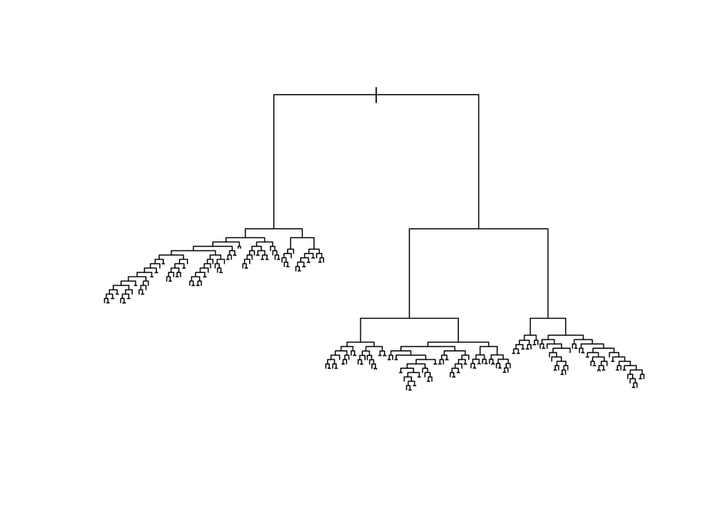

```r
set.seed(2)
original_tree <- rpart(Control_factor ~ ., method = "class",
                          data = data_training,control = rpart.control(cp=0,minsplit = 0))

plot(original_tree)
```

Based on the tree plot, the original tree is very large, which is subject to an overfitting problem and may lead to a poor generalization to unseen data. So we want to alleviate the overfitting problem by adjusting some parameters of the model.

We used **Grid Search** to help up find the best `cp` and `minsplit` that can yield the highest model accuracy. `cp` parameter helps to adjust model complexity and `minsplit` determines the minimum number of observations that must exist in a node, in order for a split to be attempted.

Considering that the Grid Search for `rpart` is only able to tune the `cp` parameter, we would like to find the best `cp` value for a set of `minsplit` values: **30**, **50** and **80**, and then compare accuracy of these three models to get the best parameter combination.

```r
set.seed(42)
# prepare training scheme, create a control object to control how the train function creates the model
control <- trainControl(method="repeatedcv", number=5, repeats = 3)

# design the parameter tuning grid
grid <- expand.grid(cp = c(0.001,0.003,0.01))

set.seed(42)

# train the model
model1 <- train(Control_factor~., data=data_training, method="rpart",
                trControl=control,
                tuneGrid=grid,
                minsplit=30)  #additional parameter
model1
```

```
## CART
##
## 3018 samples
##   14 predictor
##    3 classes: 'Private For-profit', 'Private Nonprofit', 'Public'
##
## No pre-processing
## Resampling: Cross-Validated (5 fold, repeated 3 times)
## Summary of sample sizes: 2414, 2415, 2415, 2414, 2414, 2415, ...
## Resampling results across tuning parameters:
##
##   cp     Accuracy   Kappa
##   0.001  0.8792758  0.8105763
##   0.003  0.8773999  0.8069140
##   0.010  0.8527703  0.7667662
##
## Accuracy was used to select the optimal model using  the largest value.
## The final value used for the model was cp = 0.001.
```

```r
model2 <- train(Control_factor~., data=data_training, method="rpart",

                trControl=control,
                tuneGrid=grid,
                 minsplit=50)
model2
```

```
## CART
##
## 3018 samples
##   14 predictor
##    3 classes: 'Private For-profit', 'Private Nonprofit', 'Public'
##
## No pre-processing
## Resampling: Cross-Validated (5 fold, repeated 3 times)
## Summary of sample sizes: 2415, 2414, 2414, 2414, 2415, 2414, ...
## Resampling results across tuning parameters:
##
##   cp     Accuracy   Kappa
##   0.001  0.8855756  0.8201542
##   0.003  0.8839198  0.8172812
##   0.010  0.8585154  0.7758146
##
## Accuracy was used to select the optimal model using  the largest value.
## The final value used for the model was cp = 0.001.
```

```r
model3 <- train(Control_factor~., data=data_training, method="rpart",
                trControl=control,
                tuneGrid=grid,
                minsplit=80)
model3
```

```
## CART
##
## 3018 samples
##   14 predictor
##    3 classes: 'Private For-profit', 'Private Nonprofit', 'Public'
##
## No pre-processing
## Resampling: Cross-Validated (5 fold, repeated 3 times)
## Summary of sample sizes: 2415, 2414, 2415, 2413, 2415, 2415, ...
## Resampling results across tuning parameters:
##
##   cp     Accuracy   Kappa
##   0.001  0.8850204  0.8194841
##   0.003  0.8854672  0.8198514
##   0.010  0.8601714  0.7781251
##
## Accuracy was used to select the optimal model using  the largest value.
## The final value used for the model was cp = 0.003.
```

With the above code block, the `model1` object lists the Accuracy values for three levels of **0.001**, **0.003**, **0.010**, given the `minsplit` is 30; the `model2` object lists the Accuracy values for three levels of **0.001**, **0.003**, **0.010**, given the `minsplit` is 50; the `model3` object lists the Accuracy values for three levels of **0.001**, **0.003**, **0.010**, given the `minsplit` is 80.

Then we selected the parameter combinations which lead to the highest accuracy value for each minsplit value.

```r
#best for minsplit = 20
model1$results[which.max(model1$results[,c('Accuracy')]),c('cp','Accuracy')]
```

```
##      cp  Accuracy
## 1 0.001 0.8792758
```

```r
#best for minsplit =50
model2$results[which.max(model2$results[,c('Accuracy')]),c('cp','Accuracy')]
```

```
##      cp  Accuracy
## 1 0.001 0.8855756
```

```r
#best for minsplit = 80
model3$results[which.max(model3$results[,c('Accuracy')]),c('cp','Accuracy')]
```

```
##      cp  Accuracy
## 2 0.003 0.8854672
```

Based on the output, we can see that the model with minsplit = 50 and cp = 0.001 gives the highest model accuracy: 0.8855756.

Then we rebuilt the tree with the control parameters: `cp = 0.001` and `minsplit = 50`. A tree plot was also plotted with `fancyRpartPlot` function.

[figure not shown]

```r
tree_tuned <- rpart(Control_factor ~ ., method = "class",
                          data = data_training,control = rpart.control(
                          cp=0.001,
                          minsplit = 50))
fancyRpartPlot(tree_tuned)
```

Based on the tree plot, the new tree has a more reasonable size than the original tree. However, the new tree is still complicated, which may still have an overfitting issue. We used the cross validation error to prune the tree to avoid overfitting the data.

The `printcp` function allows us to select a tree size that minimizes the cross-validated error. After the tree size is determined, we can prune the tree with the corresponding **cp** value and generate a new tree with `prune` function.

```r
printcp(tree_tuned)
```

```
##
## Classification tree:
## rpart(formula = Control_factor ~ ., data = data_training, method = "class",
##     control = rpart.control(cp = 0.001, minsplit = 50))
##
## Variables actually used in tree construction:
## [1] APPL_SCH_PCT_GE2  DEP_STAT_PCT_IND  MD_EARN_WNE_P10   MD_FAMINC
## [5] NPT4_COMBINE      PAR_ED_PCT_1STGEN PCTFLOAN          PREDDEG_factor
## [9] RPY_3YR_RT_SUPP
##
## Root node error: 1631/3018 = 0.54042
##
## n= 3018
##
##           CP nsplit rel error  xerror     xstd
## 1  0.3439608      0   1.00000 1.00000 0.016786
## 2  0.2293072      1   0.65604 0.65788 0.016123
## 3  0.0613121      2   0.42673 0.43716 0.014308
## 4  0.0435316      3   0.36542 0.38320 0.013649
## 5  0.0260576      4   0.32189 0.33783 0.013012
## 6  0.0128755      6   0.26977 0.28755 0.012203
## 7  0.0110362      7   0.25690 0.28020 0.012074
## 8  0.0107296      8   0.24586 0.27897 0.012052
## 9  0.0088903     10   0.22440 0.27100 0.011909
## 10 0.0085837     12   0.20662 0.25628 0.011635
## 11 0.0073574     13   0.19804 0.24647 0.011445
## 12 0.0042918     14   0.19068 0.23544 0.011224
## 13 0.0026569     15   0.18639 0.23115 0.011136
## 14 0.0024525     18   0.17842 0.23360 0.011187
## 15 0.0010000     19   0.17597 0.23666 0.011249
```

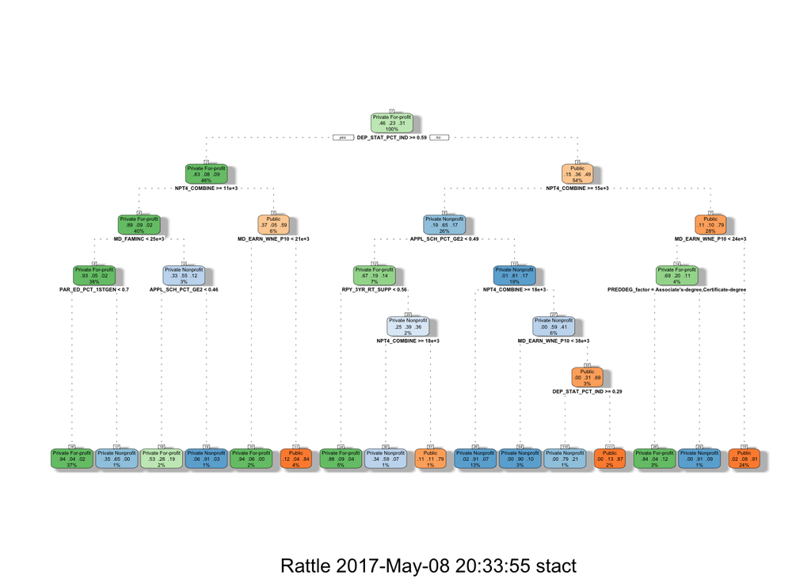

```r
bestcp <- tree_tuned$cptable[which.min(tree_tuned$cptable[,"xerror"]),
                                 "CP"]
tree.pruned <- prune(tree_tuned, cp = bestcp)

fancyRpartPlot(tree.pruned)
```

Then we used the `maxdepth` parameter to adjust the tree size, limiting the tree level to only 3.

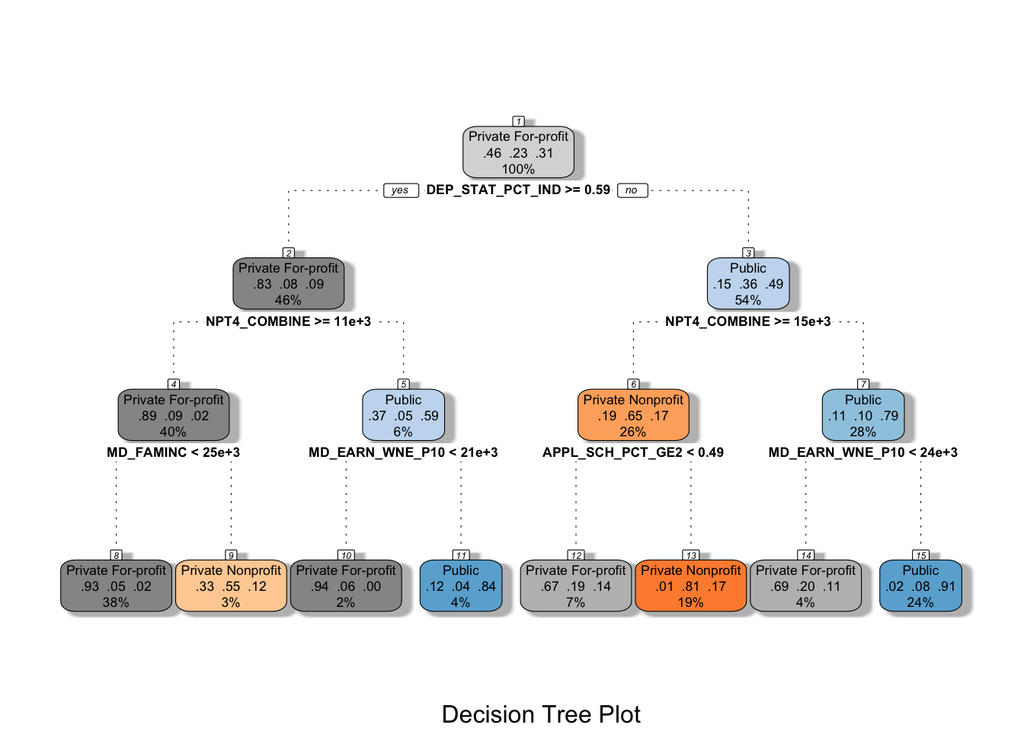

```r
tree.pruned.limited <- rpart(Control_factor ~ ., method = "class",
                          data = data_training,control = rpart.control(
                          cp=0.001,
                          minsplit = 50,
                          maxdepth = 3))

fancyRpartPlot(tree.pruned.limited, sub = 'Decision Tree Plot', palettes=c("Greys", "Oranges","Blues"))
```

Based on the tree plot, the final tree model has only 8 terminal nodes, which is in a reasonable size. After having an understanding of how the tree look like, we also want to evaluate how well the tree performs in terms of the predictive accuracy. The following sections compared the predicted values from the final model with the true values for both training data and testing data.

We used `tree.pruned.limited` model to generate predictions on the training set and check the model accuracy with a confusion matrix.

```r
train_preds = predict (tree.pruned.limited,
                       newdata = data_training,
                       type="class")
confusionMatrix(train_preds, data_training$Control_factor)
```

```
## Confusion Matrix and Statistics
##
##                     Reference
## Prediction           Private For-profit Private Nonprofit Public
##   Private For-profit               1328               128     63
##   Private Nonprofit                  34               510    110
##   Public                             25                62    758
##
## Overall Statistics
##
##                Accuracy : 0.8602
##                  95% CI : (0.8473, 0.8724)
##     No Information Rate : 0.4596
##     P-Value [Acc > NIR] : < 2.2e-16
##
##                   Kappa : 0.7788
##  Mcnemar's Test P-Value : < 2.2e-16
##
## Statistics by Class:
##
##                      Class: Private For-profit Class: Private Nonprofit
## Sensitivity                             0.9575                   0.7286
## Specificity                             0.8829                   0.9379
## Pos Pred Value                          0.8743                   0.7798
## Neg Pred Value                          0.9606                   0.9196
## Prevalence                              0.4596                   0.2319
## Detection Rate                          0.4400                   0.1690
## Detection Prevalence                    0.5033                   0.2167
## Balanced Accuracy                       0.9202                   0.8332
##                      Class: Public
## Sensitivity                 0.8142
## Specificity                 0.9583
## Pos Pred Value              0.8970
## Neg Pred Value              0.9204
## Prevalence                  0.3085
## Detection Rate              0.2512
## Detection Prevalence        0.2800
## Balanced Accuracy           0.8862
```

The diagonal of the Confusion Matrix indicates the instances that are correctly classified in the training data set. We see that for training data set, 2596 instances are classified correctly, and the model has an accuracy of 0.8602 on the training data set.

As it is usual for the predictive model to perform well on the data set used to create it, let’s use the model to make predictions on the test data set to see how well it performs on the unseen data.

```r
test_preds = predict (tree.pruned.limited,
                       newdata = data_testing,
                       type="class")
confusionMatrix(test_preds, data_testing$Control_factor)
```

```
## Confusion Matrix and Statistics
##
##                     Reference
## Prediction           Private For-profit Private Nonprofit Public
##   Private For-profit                637                57     45
##   Private Nonprofit                  24               305     61
##   Public                             18                27    336
##
## Overall Statistics
##
##                Accuracy : 0.8464
##                  95% CI : (0.8272, 0.8642)
##     No Information Rate : 0.4497
##     P-Value [Acc > NIR] : < 2.2e-16
##
##                   Kappa : 0.7598
##  Mcnemar's Test P-Value : 2.624e-08
##
## Statistics by Class:
##
##                      Class: Private For-profit Class: Private Nonprofit
## Sensitivity                             0.9381                   0.7841
## Specificity                             0.8773                   0.9242
## Pos Pred Value                          0.8620                   0.7821
## Neg Pred Value                          0.9455                   0.9250
## Prevalence                              0.4497                   0.2576
## Detection Rate                          0.4219                   0.2020
## Detection Prevalence                    0.4894                   0.2583
## Balanced Accuracy                       0.9077                   0.8541
##                      Class: Public
## Sensitivity                 0.7602
## Specificity                 0.9579
## Pos Pred Value              0.8819
## Neg Pred Value              0.9061
## Prevalence                  0.2927
## Detection Rate              0.2225
## Detection Prevalence        0.2523
## Balanced Accuracy           0.8590
```

With the following code block, we interpreted the final model by plotting the final tree and requesting the summary statistics.

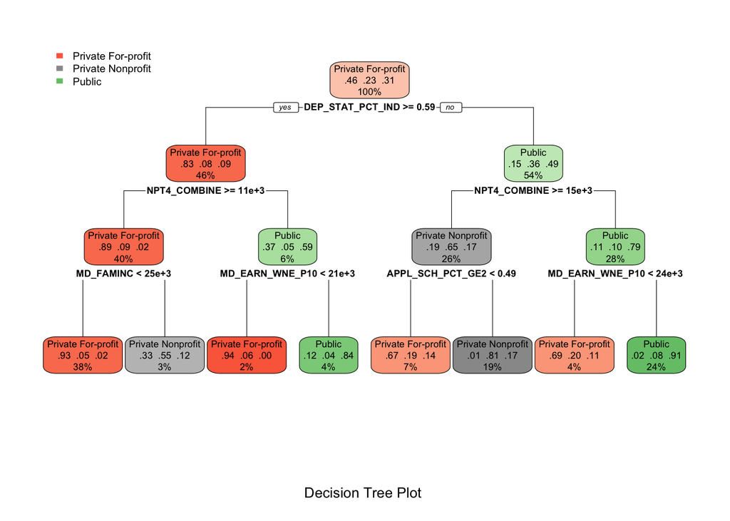

```r
rpart.plot(tree.pruned.limited, sub = 'Decision Tree Plot')
```

```r
print(tree.pruned.limited)
```

```
## n= 3018
##
## node), split, n, loss, yval, (yprob)
##       * denotes terminal node
##
##  1) root 3018 1631 Private For-profit (0.45957588 0.23194168 0.30848244)
##    2) DEP_STAT_PCT_IND>=0.5931413 1387  242 Private For-profit (0.82552271 0.08219178 0.09228551)
##      4) NPT4_COMBINE>=10752.5 1218  135 Private For-profit (0.88916256 0.08702791 0.02380952)
##        8) MD_FAMINC< 24511.41 1136   80 Private For-profit (0.92957746 0.05369718 0.01672535) *
##        9) MD_FAMINC>=24511.41 82   37 Private Nonprofit (0.32926829 0.54878049 0.12195122) *
##      5) NPT4_COMBINE< 10752.5 169   70 Public (0.36686391 0.04733728 0.58579882)
##       10) MD_EARN_WNE_P10< 21400 51    3 Private For-profit (0.94117647 0.05882353 0.00000000) *
##       11) MD_EARN_WNE_P10>=21400 118   19 Public (0.11864407 0.04237288 0.83898305) *
##    3) DEP_STAT_PCT_IND< 0.5931413 1631  828 Public (0.14837523 0.35928878 0.49233599)
##      6) NPT4_COMBINE>=14558 780  276 Private Nonprofit (0.18717949 0.64615385 0.16666667)
##       12) APPL_SCH_PCT_GE2< 0.4916888 208   69 Private For-profit (0.66826923 0.18750000 0.14423077) *
##       13) APPL_SCH_PCT_GE2>=0.4916888 572  107 Private Nonprofit (0.01223776 0.81293706 0.17482517) *
##      7) NPT4_COMBINE< 14558 851  178 Public (0.11280846 0.09635723 0.79083431)
##       14) MD_EARN_WNE_P10< 24350 124   39 Private For-profit (0.68548387 0.20161290 0.11290323) *
##       15) MD_EARN_WNE_P10>=24350 727   68 Public (0.01513067 0.07840440 0.90646492) *
```

From the plot, we can tell `DEP_STAT_PCT_IND`(Percentage of students who are financially independent) is the most important variable to predict the control type of a school, `NPT4_COMBINE`(average net price for TITLE IV institutions of both public and private.), `MD_FAMINC`(Median family income in real 2015 dollars), `MD_EARN_WNE_P10`(Median income ten years after entry) and `APPL_SCH_PCT_GE2`(Percentage of students submitting 2 or more than 2 applications) are also the important variables.

As seen from the plot, in each node shows: 1. The predicted class (Private For-profit, Private Nonprofit and Public) 2. The predicted probability of each class 3. The percentage of observations in this node

Below are the 8 rules concluded from the final tree model:

For private for-profit schools:

*Rule 1* (38% of all instituions):

If an school has Percentage of students who are financially independent >= 0.59, average net price for TITLE IV institutions of both public and private >= 10752.5, Median family income in real 2015 dollars < 24511.41, then this school is classified as the control type of **Private For-profit**. This is the typical profile of private for-profit schools.

*Rule 2*(7% of all institutions):

if an school has Percentage of students who are financially independent < 0.59, average net price for TITLE IV institutions of both public and private >=14558, Percentage of students submitting 2 or more than 2 applications < 0.49, then this school is classified as the control type of **Private For-profit**.

*Rule 3*(4% of all institutions):

if an school has Percentage of students who are financially independent < 0.59, average net price for TITLE IV institutions of both public and private < 14558, Median income ten years after entry < 24350, then this school is classified as the control type of **Private For-profit**.

For private non-profit schools:

*Rule 5*(19% of all institutions):

if an school has Percentage of students who are financially independent < 0.59, average net price for TITLE IV institutions of both public and private >=14558, Percentage of students submitting 2 or more than 2 applications >= 0.49, then this school is classified as the control type of **Private Non-profit**. This is the typical profile of private non-profit schools

*Rule 6*(3% of all institutions):

if an school has Percentage of students who are financially independent >= 0.59, average net price for TITLE IV institutions of both public and private >= 10752.5, Median family income in real 2015 dollars >= 24511.41, then this school is classified as the control type of **Private Non-profit**

For public schools:

*Rule 7*(24% of all institutions):

if an school has Percentage of students who are financially independent < 0.59, average net price for TITLE IV institutions of both public and private < 14558, Median income ten years after entry >= 24350, then this school is classified as the control type of **Public**. This is the typical profile of public schools.

In the following part, we used another algorithm - K-nearest Neighbor to classify a school’s control type. Then we compared the performance of two final models to compare which model performs better in terms of classification ability.

# 4. k-Nearest Neighbour Classification

First of all, we imported the training and testing data we created in the 1st part, and removed the unnecessary column from the data set.

```r
#training
data_k_d= read.csv("Data_training.csv",
                   header = TRUE, na.strings = 'NA')
data_training_k <- data.frame(data_k_d[,-1])

#testing
data_k_d2 = read.csv("Data_testing.csv",
                   header = TRUE, na.strings = 'NA')
data_testing_k = data.frame(data_k_d2[,-1])
```

Accordingly, `data_training_k` and `data_testing_k` are the resulting data sets.

Then we encoded the factor variables into dummy variables to calculate the distance metrics between each pair of instances when implementing KNN. In our data set, only one factor variable `PREDDEG_factor` (Predominant Degree) needs to be converted. We created a function `convertNum()` to automate the entire conversion process.

```r
convertNum = function(mydata) {
    mydata = mydata[,-1]
    dummy_preddeg = model.matrix(~PREDDEG_factor-1,mydata)

    colnames(dummy_preddeg) <- gsub("PREDDEG_factor","",colnames(dummy_preddeg))

    data_combine = cbind(mydata, dummy_preddeg)
    return (data.frame(data_combine[,-1]))  #get rid of the converted col PRED
}
```

The function encodes the factor variable `PREDDEG_factor` into dummies, renames the new columns and drops the original factor variable after the new data set is integrated.

Then we applied the function to the training and testing data to perform data transformation.

```r
data_knn_training = convertNum(data_k_d)
data_knn_testing = convertNum(data_k_d2)
```

`data_knn_training` and `data_knn_testing` are the resulting data sets.

Next, we used KNN algorithm to build a KNN model. `train.kknn` performs leave-one-out cross validation and is computationally very efficient. We set kmax = 9 so the number of nearest neighbor from 1 to 9 will be considered. The `train.kknn` function is also able to find out the best kernal among `triangular`,`rectangular`,`epanechnikov` and `optimal`. We set `scale` to TRUE to ensure every variable receives an equal weight. With the `plot` function, we can get a plot to show the performance of model with each kernel for different k values.

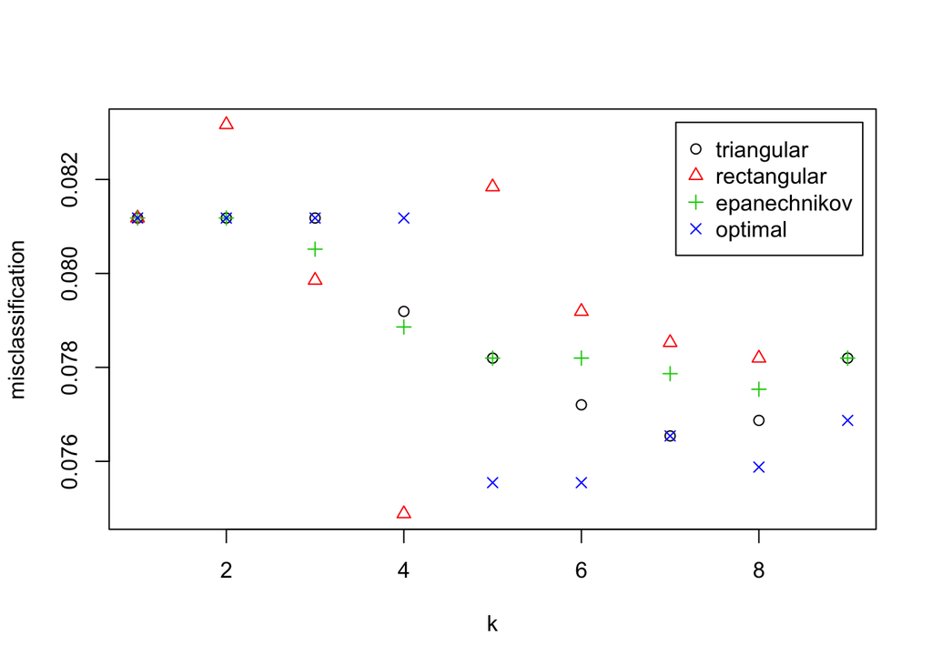

```r
model <- train.kknn(Control_factor ~ .,
                    data = data_knn_training,
                    kmax = 9,
                    scale = TRUE,
                    kernel = c("triangular", "rectangular", "epanechnikov", "optimal"))

plot(model)
```

```r
model #display the summary
```

```
##
## Call:
## train.kknn(formula = Control_factor ~ ., data = data_knn_training,     kmax = 9, kernel = c("triangular", "rectangular", "epanechnikov",         "optimal"), scale = TRUE)
##
## Type of response variable: nominal
## Minimal misclassification: 0.07488403
## Best kernel: rectangular
## Best k: 4
```

From the result we see that the when k=4, the model generates the best result - 7.5% classifications rate. Also, the best kernel is **rectangular kernel**, which is also can be concluded from the plot. Moreover, the plot also indicates that an optimal kernel with k = 5,6,8 can also generate a model with low misclassification rates.

After the model is built, we need to evaluate how the model performs on both training and testing data. With the `confusionMatrix` function, we can get the confusion matrix for classification and the model performance for each class.

```r
#training error
prediction_training <- predict(model, data_knn_training[, -1])
confusionMatrix(reference=data_knn_training[, 1], data=prediction_training )
```

```
## Confusion Matrix and Statistics
##
##                     Reference
## Prediction           Private For-profit Private Nonprofit Public
##   Private For-profit               1365                42     11
##   Private Nonprofit                  13               612     21
##   Public                              9                46    899
##
## Overall Statistics
##
##                Accuracy : 0.9529
##                  95% CI : (0.9448, 0.9602)
##     No Information Rate : 0.4596
##     P-Value [Acc > NIR] : < 2.2e-16
##
##                   Kappa : 0.9261
##  Mcnemar's Test P-Value : 1.684e-05
##
## Statistics by Class:
##
##                      Class: Private For-profit Class: Private Nonprofit
## Sensitivity                             0.9841                   0.8743
## Specificity                             0.9675                   0.9853
## Pos Pred Value                          0.9626                   0.9474
## Neg Pred Value                          0.9863                   0.9629
## Prevalence                              0.4596                   0.2319
## Detection Rate                          0.4523                   0.2028
## Detection Prevalence                    0.4698                   0.2140
## Balanced Accuracy                       0.9758                   0.9298
##                      Class: Public
## Sensitivity                 0.9656
## Specificity                 0.9736
## Pos Pred Value              0.9423
## Neg Pred Value              0.9845
## Prevalence                  0.3085
## Detection Rate              0.2979
## Detection Prevalence        0.3161
## Balanced Accuracy           0.9696
```

The overall accuracy of the model is 95%, which indicates that the model has a very good performance on the training data set. Looking at the Sensitivity and Specificity for each class, we can also tell the model has a good prediction power given the high Sensitivity value and high Specificity value.

Then we predict the model on the testing data set.

```r
#testing
prediction_testing  <- predict(model, data_knn_testing[, -1])
confusionMatrix(reference=data_knn_testing[, 1], data=prediction_testing)
```

```
## Confusion Matrix and Statistics
##
##                     Reference
## Prediction           Private For-profit Private Nonprofit Public
##   Private For-profit                651                16     11
##   Private Nonprofit                  18               323     16
##   Public                             10                50    415
##
## Overall Statistics
##
##                Accuracy : 0.9199
##                  95% CI : (0.905, 0.9331)
##     No Information Rate : 0.4497
##     P-Value [Acc > NIR] : < 2.2e-16
##
##                   Kappa : 0.8758
##  Mcnemar's Test P-Value : 0.0005119
##
## Statistics by Class:
##
##                      Class: Private For-profit Class: Private Nonprofit
## Sensitivity                             0.9588                   0.8303
## Specificity                             0.9675                   0.9697
## Pos Pred Value                          0.9602                   0.9048
## Neg Pred Value                          0.9663                   0.9428
## Prevalence                              0.4497                   0.2576
## Detection Rate                          0.4311                   0.2139
## Detection Prevalence                    0.4490                   0.2364
## Balanced Accuracy                       0.9631                   0.9000
##                      Class: Public
## Sensitivity                 0.9389
## Specificity                 0.9438
## Pos Pred Value              0.8737
## Neg Pred Value              0.9739
## Prevalence                  0.2927
## Detection Rate              0.2748
## Detection Prevalence        0.3146
## Balanced Accuracy           0.9414
```

We see that the overall accuracy of the model on testing set is 92%, slightly lower than on the training data set. The Sensitivity and Specificity for each class is lower than training data set, but is still falling into an acceptable range. As a conclusion, the KNN final model performs well on both training and testing data.

# 5. Conclusions

In the above analysis, we used Decision Tree model and K-nearest Neighbor model to classify the Control Type (`control_factor`) variable.

The decision tree model gives an accuracy score of 0.8602 on the training data set and an accuracy score of 0.8464 on the testing data set while the KNN model gives an accuracy score of 0.95 on the training data set and an accuracy score of 0.92 on the testing data set. Overally speaking, KNN model yields a better accuracy than we achieved with the tree-based model, but the two final models both have a very good performance, which suggests that the existing features are able to distinguish one type of school from another very effectively.

Two models have their own strengths and weakness. Decision tree is one of the “Eager Learners”, which are designed to learn a model that maps the input attributes as soon as the training data set is available: they first build a classification model on the training data set before being able to actually classify an unseen observation from test data set. KNN is one of the “Lazy Learners”, the classifier delays the process of modeling the training data set until it is needed to classify the test examples: it does not build any classification model. It directly learns from the training observations and starts processing data only after it is given a test observation to classify.

Additionally, Decision Tree is very easy to interpret while KNN outperforms decision tree in terms of the prediction power. Therefore, it’s better to use KNN model for prediction rather than classification.

To sum up, KNN is a better choice when used for prediction while decision tree is easier to understand, especially for interpretation and presentation.

# 6. Future Studies

One question we would like to address in the future is to find a better algorithm to perform parameters tuning. Although there are many tunable parameters in decision tree analysis, the Grid Search algorithm in `caret` package can only allow us to tune the `cp` parameter. In Python, Grid Search allows us to test a combination of many parameters at the same time when building the decision tree, thus it would be helpful if we can find a counterpart in R.

Additionally, other classification algorithms like **Random Forest**, **Neural Network** and **Support Vector Machine** are also worth trying, which allows us to explore other potential models with better performances.